# Pilot Data Analysis

Bradley Kennedy

10/07/2018

### The aim of the code below is to restructure the dataset into a suitable layout to calculate descriptive statistics by group

If packages are not already installed, do so

```r
if (!require("dplyr")) install.packages("dplyr")
if (!require("beepr")) install.packages("beepr")
if (!require("readxl")) install.packages("readxl")
if (!require("data.table")) install.packages("data.table")
if (!require("readr")) install.packages("readr")
if (!require("tidyverse")) install.packages("tidyverse")
if (!require("tidyr")) install.packages("tidyr")
if (!require("ggplot2")) install.packages("ggplot2")
if (!require("ggpubr")) install.packages("ggpubr")
if (!require("reshape2")) install.packages("reshape2")
if (!require("RColorBrewer")) install.packages("RColorBrewer")
if (!require("ggthemes")) install.packages("ggthemes")
if (!require("stringr")) install.packages("stringr")
library (dplyr)
library (beepr)
library (readxl)
library(data.table)
library(readr)
library(tidyverse)
library(tidyr)
library(ggplot2)
library(ggpubr)
library(reshape2)
library(RColorBrewer)
library(ggthemes)
library(stringr)
```

Check for package updates

```r
update.packages(ask=FALSE, repos = "https://cloud.r-project.org")
```

Load the dataset

```r
pilotdata_v1 <- pilot_study_data_ANON
```

Transform characteristic ratings to numbers

```r
pilotdata_v2 <- mutate_at(pilotdata_v1, vars(9:647), funs(ifelse( . == "1 - Not very ..." , 1, ifelse(. == "2", 2, ifelse( . == "3 - Moderately ...", 3, ifelse(. == "4", 4, ifelse( . == "5 - Very ...", 5, .)))))))
```

Transform sector ratings to numbers

```r
pilotdata_v2 <- mutate_at(pilotdata_v2, vars(649:656), funs(ifelse( . == "1. Very Negative" , 1, ifelse(. == "2. Negative", 2, ifelse( . == "3. Neutral", 3, ifelse(. == "4. Positive", 4, ifelse( . == "5. Very Positive", 5, .)))))))
```

Reverse code Dishonest and Selfish in first eight job roles

```r
pilotdata_v2 <- mutate_at(pilotdata_v2, vars(11,14,21,24,31,34,41,44,51,54,61,64,71,74,81,84), funs(ifelse( . == 1 , 5, ifelse(. == 2, 4, ifelse( . == 3, 3, ifelse(. == 4, 2, ifelse( . == 5, 1, .)))))))
```

Rename variables now they have been reversed - Dishonest <- Honest & Selfish <- Charitable

```r
names(pilotdata_v2)[11] <- "7.3._Honest"
names(pilotdata_v2)[21] <- "8.3._Honest"
names(pilotdata_v2)[31] <- "9.3._Honest"
names(pilotdata_v2)[41] <- "10.3._Honest"
names(pilotdata_v2)[51] <- "11.3._Honest"
names(pilotdata_v2)[61] <- "12.3._Honest"
names(pilotdata_v2)[71] <- "13.3._Honest"
names(pilotdata_v2)[81] <- "14.3._Honest"
names(pilotdata_v2)[14] <- "7.6._Charitable"
names(pilotdata_v2)[24] <- "8.6._Charitable"
names(pilotdata_v2)[34] <- "9.6._Charitable"
names(pilotdata_v2)[44] <- "10.6._Charitable"
names(pilotdata_v2)[54] <- "11.6._Charitable"
names(pilotdata_v2)[64] <- "12.6._Charitable"
names(pilotdata_v2)[74] <- "13.6._Charitable"
names(pilotdata_v2)[84] <- "14.6._Charitable"
```

Remove non-required columns - understood confirmation, consent, gender, age, academic year, rps code, start time, end time

```r
pilotdata_v3 <- select(pilotdata_v2, -2:-7, -657:-658)
```

Remove spaces from variable names, replace with period

```r
names(pilotdata_v3) <- str_replace_all(names(pilotdata_v3), c(" " = "."))
```

Remove first 5 characters (6 characters from those with double digits) from characteristics column names

```r
i1 <- unlist(Map(":", seq(3, 23, by = 10), seq(11, 31, by = 10)))
i2 <- unlist(Map(":", seq(33, 633, by = 10), seq(41, 641, by = 10)))
names(pilotdata_v3)[i1] <- substring(names(pilotdata_v3)[i1], 6)
names(pilotdata_v3)[i2] <- substring(names(pilotdata_v3)[i2], 7)
```

Remove first 6 characters from sector column names

```r
names(pilotdata_v3)[643:650] <- substring(names(pilotdata_v3)[643:650],7)
```

Code column names.

```r
addToCol <- c("1_m_med_ed_","2_f_edu_vc_","3_m_gov_barr_","4_f_mil_gen_","5_f_heal_stnur_","6_m_bus_wait_","7_m_edu_head_","8_m_med_proof_","9_f_bus_bar_","10_m_bus_admin_","11_m_heal_vet_","12_f_edu_ta_","13_f_gov_mp_","14_f_bus_ceo_","15_m_heal_stnur_","16_m_med_tv_","17_m_bus_bar_","18_f_med_ed_","19_m_mil_entr_","20_m_bus_barist_","21_f_bus_super_","22_f_bus_acc_","23_m_bus_ceo_","24_m_heal_doc_","25_m_bus_elect_","26_m_pubt_driver_","27_f_heal_clean_","28_f_edu_head_","29_m_bus_shelf_","30_m_bus_prop_","31_f_med_proof_","32_m_edu_vc_","33_f_bus_elect_","34_f_bus_retail_","35_m_gov_bin_","36_m_bus_acc_","37_f_bus_wait_","38_f_pubt_pilot_","39_m_gov_civil_","40_m_gov_mp_","41_m_bus_retail_","42_f_heal_vet_","43_f_bus_admin_","44_f_gov_civil_","45_f_gov_bin_","46_m_heal_clean_","47_m_pubt_pilot_","48_f_med_tv_","49_f_heal_doc_","50_f_bus_olymp_","51_m_edu_ta_","52_m_bus_appelect_","53_f_bus_barist_","54_f_bus_prop_","55_m_mil_gen_","56_m_med_tvcam_","57_m_mil_entr_","58_f_pubt_driver_","59_m_bus_olymp_","60_f_gov_barr_","61_f_bus_appelect_","62_f_bus_shelf_","63_m_bus_super_","64_f_med_tvcam_")
i3 <- unlist(Map(":", seq(3, 633, by = 10), seq(11, 641, by = 10)))
names(pilotdata_v3)[i3] <- paste0(rep(addToCol, each = 9), names(pilotdata_v3)[i3])
```

Remove blank columns (i.e. those columns with only NA values)

```r
pilotdata_v3 <- pilotdata_v3[,colSums(is.na(pilotdata_v3))<nrow(pilotdata_v3)]
```

Put Sector data into a seperate data frame

```r
sector_pilotdata_v1 <- select(pilotdata_v3, 1, 578:585)
```

Remove the sector data from characteristic data

```r
pilotdata_v3 <- select(pilotdata_v3, -578:-585)
```

Turn into long format

```r
names <-colnames(pilotdata_v3)[-1]
data_long <- gather(pilotdata_v3, "Question", "Response", c(names))
newdata <- data_long[order(data_long$ResponseID),]
temp <- separate(data_long, col="Question", into=c("Question", "Gender", "Sector", "Job", "Characteristic"), sep="_")
newdata_filt <- (is.na(temp$Response))
newdata1 <- temp [!newdata_filt,]
pilotdata_v4 <- newdata1[order(newdata1$ResponseID),]
```

### Descriptive Statistics

Characteristic means. 1=Not very 3=Moderately 5=Very

```r
descrip <- group_by(pilotdata_v4, Gender, Sector, Job, Characteristic)
getdescrip <- summarise(descrip, Response=mean(as.numeric(Response)))
getdescrip$Response <- round(getdescrip$Response, digits=2)
getdescrip <- getdescrip[order(getdescrip$Job),]
```

Sector means - 1=Very negative 2=Negative 3=Neutral 4=Positive 5=Very Positive

```r
sector_pilotdata_v1 <- transform(sector_pilotdata_v1, Military = as.numeric(Military), Education = as.numeric(Education),Business = as.numeric(Business),Charity =as.numeric(Charity),Media = as.numeric(Media),Government =as.numeric(Government),Health = as.numeric(Health),Public.transport = as.numeric(Public.transport))
sector_pilotdata_v1 <- select(sector_pilotdata_v1, -1)
sector_means <- colMeans(sector_pilotdata_v1[sapply(sector_pilotdata_v1, is.numeric)])
sector_means <- round(sector_means, digits=2)
```

Create plots of high rank and low rank matched jobs

```r
ed_proof_df <- getdescrip %>% filter(Job == 'ed' | Job == 'proof')
ed_proof_plot <- ggplot(ed_proof_df, aes(x=Characteristic, y=Response, shape=Job, colour=Gender)) + geom_point(size=3) + labs(title="Editor vs Proof reader") + theme(axis.text.x = element_text(size = 6.5))
vc_ta_df <- getdescrip %>% filter(Job == 'vc' | Job == 'ta')
vc_ta_plot <- ggplot(vc_ta_df, aes(x=Characteristic, y=Response, shape=Job, colour=Gender)) + geom_point(size=3) + labs(title="Vice Chancellor vs Teaching assistant ") + theme(axis.text.x = element_text(size = 6.5))
barr_civil_df <- getdescrip %>% filter(Job == 'barr' | Job == 'civil')
barr_civil_plot <- ggplot(barr_civil_df, aes(x=Characteristic, y=Response, shape=Job, colour=Gender)) + geom_point(size=3) + labs(title="Barrister vs Civil Servant") + theme(axis.text.x = element_text(size = 6.5))
gen_entr_df <- getdescrip %>% filter(Job == 'gen' | Job == 'entr')
gen_entr_plot <- ggplot(gen_entr_df, aes(x=Characteristic, y=Response, shape=Job, colour=Gender)) + geom_point(size=3) + labs(title="General/Army vs Entry level military") + theme(axis.text.x = element_text(size = 6.5))
ceo_admin_df <- getdescrip %>% filter(Job == 'ceo' | Job == 'admin')
ceo_admin_plot <- ggplot(ceo_admin_df, aes(x=Characteristic, y=Response, shape=Job, colour=Gender)) + geom_point(size=3) + labs(title="CEO vs Admin") + theme(axis.text.x = element_text(size = 6.5))
tv_tvcam_df <- getdescrip %>% filter(Job == 'tv' | Job == 'tvcam')
tv_tvcam_plot <- ggplot(tv_tvcam_df, aes(x=Characteristic, y=Response, shape=Job, colour=Gender)) + geom_point(size=3) + labs(title="TV Producer vs TV Camera operator") + theme(axis.text.x = element_text(size = 6.5))
super_shelf_df <- getdescrip %>% filter(Job == 'super' | Job == 'shelf')
super_shelf_plot <- ggplot(super_shelf_df, aes(x=Characteristic, y=Response, shape=Job, colour=Gender)) + geom_point(size=3) + labs(title="Supermarket manager vs Shelf stacker") + theme(axis.text.x = element_text(size = 6.5))
doc_stnur_df <- getdescrip %>% filter(Job == 'doc' | Job == 'stnur')
doc_stnur_plot <- ggplot(doc_stnur_df, aes(x=Characteristic, y=Response, shape=Job, colour=Gender)) + geom_point(size=3) + labs(title="Doctor vs Student nurse") + theme(axis.text.x = element_text(size = 6.5))
elect_appelect_df <- getdescrip %>% filter(Job == 'elect' | Job == 'appelect')
elect_appelect_plot <- ggplot(elect_appelect_df, aes(x=Characteristic, y=Response, shape=Job, colour=Gender)) + geom_point(size=3) + labs(title="Electrical / Aircraft Engineer  vs Apprentice electrician") + theme(axis.text.x = element_text(size = 6.5))
pilot_driver_df <- getdescrip %>% filter(Job == 'pilot' | Job == 'driver')
pilot_driver_plot <- ggplot(pilot_driver_df, aes(x=Characteristic, y=Response, shape=Job, colour=Gender)) + geom_point(size=3) + labs(title="Pilot  vs Public transport driver") + theme(axis.text.x = element_text(size = 6.5))
head_clean_df <- getdescrip %>% filter(Job == 'head' | Job == 'clean')
head_clean_plot <- ggplot(head_clean_df, aes(x=Characteristic, y=Response, shape=Job, colour=Gender)) + geom_point(size=3) + labs(title="Head teacher  vs Cleaner") + theme(axis.text.x = element_text(size = 6.5))
vet_barist_df <- getdescrip %>% filter(Job == 'vet' | Job == 'barist')
vet_barist_plot <- ggplot(vet_barist_df, aes(x=Characteristic, y=Response, shape=Job, colour=Gender)) + geom_point(size=3) + labs(title="Vet vs Barrister") + theme(axis.text.x = element_text(size = 6.5))
mp_bin_df <- getdescrip %>% filter(Job == 'mp' | Job == 'bin')
mp_bin_plot <- ggplot(mp_bin_df, aes(x=Characteristic, y=Response, shape=Job, colour=Gender)) + geom_point(size=3) + labs(title="Member of parliment vs Bin collection worker") + theme(axis.text.x = element_text(size = 6.5))
acc_wait_df <- getdescrip %>% filter(Job == 'acc' | Job == 'wait')
acc_wait_plot <- ggplot(acc_wait_df, aes(x=Characteristic, y=Response, shape=Job, colour=Gender)) + geom_point(size=3) + labs(title="Accountant vs Waiting staff (restaurant)") + theme(axis.text.x = element_text(size = 6.5))
prop_retail_df <- getdescrip %>% filter(Job == 'prop' | Job == 'retail')
prop_retail_plot <- ggplot(prop_retail_df, aes(x=Characteristic, y=Response, shape=Job, colour=Gender)) + geom_point(size=3) + labs(title="Property developer vs Retail shop assistant") + theme(axis.text.x = element_text(size = 6.5))
olymp_bar_df <- getdescrip %>% filter(Job == 'olymp' | Job == 'bar')
olymp_bar_plot <- ggplot(olymp_bar_df, aes(x=Characteristic, y=Response, shape=Job, colour=Gender)) + geom_point(size=3) + labs(title="Olympic GB Coach vs Bar staff") + theme(axis.text.x = element_text(size = 6.5))
```

Merge all plots and Export into pdf

```r
multi.page <- ggarrange(ed_proof_plot, vc_ta_plot, barr_civil_plot, gen_entr_plot,ceo_admin_plot, tv_tvcam_plot, super_shelf_plot, doc_stnur_plot, elect_appelect_plot,pilot_driver_plot,head_clean_plot,vet_barist_plot,mp_bin_plot,acc_wait_plot,prop_retail_plot,olymp_bar_plot,
          ncol = 1, nrow = 4) %>%
  ggexport(filename = "pilotdata_plots.pdf")
```

```
## file saved to pilotdata_plots.pdf
```

Plot sector means

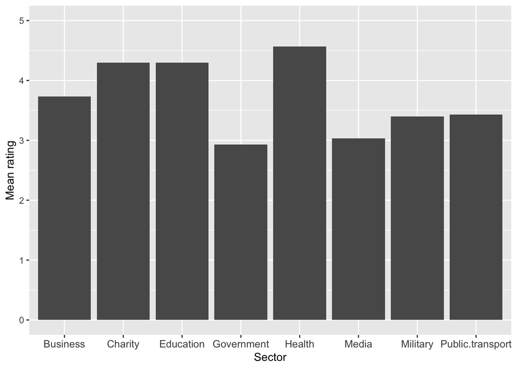

```r
sector_means <- data.frame(as.list(sector_means))
sector_long <- gather(sector_means, "Sector", "Means")
sector_means_plot <- ggplot(sector_long, aes(Sector, Means)) + geom_bar(stat="identity") + ylab("Mean rating") + ylim(0,5) + theme(axis.text.x = element_text(size = 10))
sector_means_plot
```

Reformat powerful characteristic into wide layout and exclude jobs not required

```r
powerful_df <- descrip %>% filter(Characteristic == 'Powerful')
countof_powerful <- powerful_df %>% group_by(Job, Response) %>% tally()
powerful_wide <- spread(countof_powerful, Response, n)
powerful_wide[is.na(powerful_wide)] <- 0
powerful_titles <- c("Not very", "A little", "Moderately", "Fairly", "Very")
colnames(powerful_wide) <- c("Job", powerful_titles)
powerful_wide <- tbl_df(powerful_wide)
percentage_powerful <- powerful_wide[,2:6]/rowSums(powerful_wide[,2:6])
powerful_wide[,2:6] <- percentage_powerful[1:5]
list1 <- c(2,6,8,9,10,11,12,15,16,17,20,24,25,26,27,30)
powerful_wide <- powerful_wide[list1,]
powerful_wide[,1] <- c("Admin assistant","Barrister","CEO","Civil servant","Cleaner","Doctor","Bus driver","Entry level Military","General","Head teacher","Pilot","Shelf stacker","Student nurse","Supermarket manager","Teaching assistant","Vice Chancellor")
```

# Create stacked plot

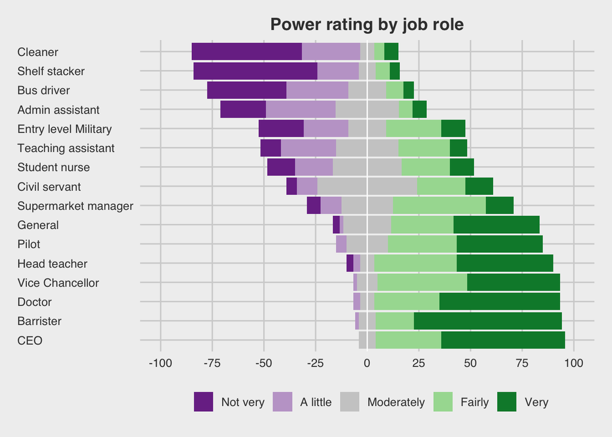

```r
tab <- powerful_wide

mytitle <- "Power rating by job role"
mylevels <- c("Not very", "A little", "Moderately", "Fairly", "Very")

numlevels<-length(tab[1,])-1
numcenter<-ceiling(numlevels/2)+1
tab$midvalues <-tab[,numcenter]/2
tab2<-cbind(tab[,1],tab[,2:ceiling(numlevels/2)], tab$midvalues, tab$midvalues, tab[,numcenter:numlevels+1])
colnames(tab2) <- c("Job", mylevels[1:floor(numlevels/2)],"midlow","midhigh",mylevels[numcenter:numlevels])

numlevels<-length(mylevels)+1
point1<-2
point2<-((numlevels)/2)+1
point3<-point2+1
point4<-numlevels+1
mymin<-(ceiling(max(rowSums(tab2[,point1:point2]))*4)/4)*-100
mymax<-(ceiling(max(rowSums(tab2[,point3:point4]))*4)/4)*100

numlevels<-length(tab[1,])-1
temp.rows<-length(tab2[,1])
pal<-brewer.pal((numlevels-1),"PRGn")
pal[ceiling(numlevels/2)]<-"gray80"
legend.pal<-pal
pal<-c(pal[1:(ceiling(numlevels/2)-1)], pal[ceiling(numlevels/2)],
       pal[ceiling(numlevels/2)], pal[(ceiling(numlevels/2)+1):(numlevels-1)])

tab3<-melt(tab2,id="Job")
tab3$col<-rep(pal,each=temp.rows)
tab3$value<-tab3$value*100
tab3$Job<-str_wrap(tab3$Job, width = 20)
tab3$Job <- as.factor(tab3$Job)
tab3$Job<-factor(tab3$Job, levels = tab2$Job[order(-(tab2[,5]+tab2[,6]+tab2[,7]))])
highs <- na.omit(tab3[(length(tab3[,1])/2)+1:length(tab3[,1]),])
lows <- na.omit(tab3[1:(length(tab3[,1])/2),])
lows <- lows[rev(rownames(lows)),]

lows <- lows %>% arrange(desc(variable))
highs <- highs %>% arrange(desc(variable))

ggplot() + geom_bar(data=highs, aes(x = Job, y=value, fill=col), position="stack", stat="identity") +
  geom_bar(data=lows, aes(x = Job, y=-value, fill=col), position="stack", stat="identity") +
  geom_hline(yintercept = 0, color =c("white")) +
  scale_fill_identity("", labels = mylevels, breaks=legend.pal, guide="legend") +
  theme_fivethirtyeight() +
  coord_flip() +
  labs(title=mytitle, y="",x="") +
  theme(plot.title = element_text(size=14, hjust=0.5)) +
  theme(axis.text.y = element_text(hjust=0)) +
  theme(legend.position = "bottom") +
  scale_y_continuous(breaks=seq(mymin,mymax,25), limits=c(mymin,mymax))
```

```r
beep(1)
```